# Predicting training quality.

Author: HagenC Practical Machine Learcning, Coursera July 31, 2016.

## **Background**

Using devices such as Jawbone Up, Nike FuelBand, and Fitbit it is now possible to collect a large amount of data about personal  
activity relatively inexpensively. These type of devices are part of the quantified self movement - a group of enthusiasts who take measurements about themselves regularly to improve their health, to find patterns in their behavior, or because they are tech geeks.  
One thing that people regularly do is quantify how much of a particular activity they do, but they rarely quantify how well they do it.  
In this project, your goal will be to use data from accelerometers on the belt, forearm, arm, and dumbell of 6 participants. They were asked to perform barbell lifts correctly and incorrectly in 5 different ways. More information is available from the website here: http://groupware.les.inf.puc-rio.br/har (see the section on the Weight Lifting Exercise Dataset).

**Data** The training data for this project are available here:  
https://d396qusza40orc.cloudfront.net/predmachlearn/pml-training.csv  
The test data are available here:  
https://d396qusza40orc.cloudfront.net/predmachlearn/pml-testing.csv

**Aim of assignment**

Creat a prediction model that can predict the “class” based on accelerometer measuremnt. The “classes”" are: - Correct performed: A - Incorrect performed: B (throwing), C (half-way), D (lowering only half-way) or E (hips to the front).

## **Importing data**

```r
pml_training_set <- "http://d396qusza40orc.cloudfront.net/predmachlearn/pml-training.csv"
pml_testing_set <- "http://d396qusza40orc.cloudfront.net/predmachlearn/pml-testing.csv"
training_org <- read.csv(url(pml_training_set), na.strings=c("NA",""))
testing_org <- read.csv(url(pml_testing_set), na.strings=c("NA",""))
```

**Dimensions of the data_sets**

```r
dim(training_org)
```

```
## [1] 19622   160
```

```r
dim(testing_org)
```

```
## [1]  20 160
```

## Data Clean-up

**Checking if there is NAs present in the datasets**

```r
table(is.na(training_org))
```

```
##
##   FALSE    TRUE
## 1217920 1921600
```

```r
table(is.na(testing_org))
```

```
##
## FALSE  TRUE
##  1200  2000
```

**Removing columns with NAs**

```r
NAs_training_org <-data.frame(sapply(training_org, function(x) sum(length(which(is.na(x))))))
keep_list <- row.names(subset(NAs_training_org, NAs_training_org[,1] == 0))
noNA_training <- subset(training_org, select = c(keep_list))
```

**Removing non relevant variables. (Ulogical predictors)**

```r
noNA_training <- noNA_training[, -c(1:7)]
```

**Cheking if some of the variables/predictors are higly correlated**

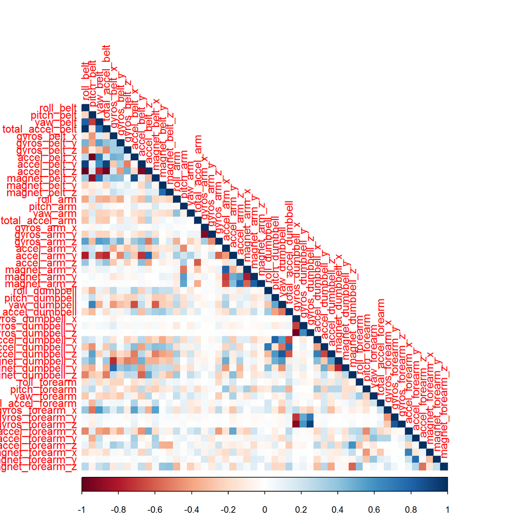

```r
corMatrix <- cor(noNA_training[, -53])
library(corrplot)
corrplot(corMatrix, method = "color", type="lower")
```

**Removing variables with a correlation above 90%**

```r
suppressPackageStartupMessages(suppressWarnings(library(caret)))
```

```
## Note: the specification for S3 class "family" in package 'MatrixModels' seems equivalent to one from package 'lme4': not turning on duplicate class definitions for this class.
```

```r
corre90_list <- findCorrelation(cor(noNA_training[, -53]), cutoff = 0.9)
noNA_training_corRemoved <- noNA_training[,-corre90_list]
```

## Prediction tests.

**Making training(60%) and test(40%) set of the original training set so we can make cross-validation**

```r
train_split <- createDataPartition(y=noNA_training_corRemoved$classe, p=0.6, list=FALSE)
training_set <- noNA_training_corRemoved[train_split,];
testing_set <- noNA_training_corRemoved[-train_split,]
dim(training_set)
```

```
## [1] 11776    46
```

```r
dim(testing_set)
```

```
## [1] 7846   46
```

#### **Decision tree (rpart)**

**Starting with a rpart as it is less computional demanding(fast) compared to other methods**

```r
set.seed(1375)
suppressPackageStartupMessages(suppressWarnings(library(rpart)))
rpart_control <- rpart.control(maxdepth = 4, xval = 10)
rpartFull <- rpart(classe~., data = training_set, control = rpart_control)
```

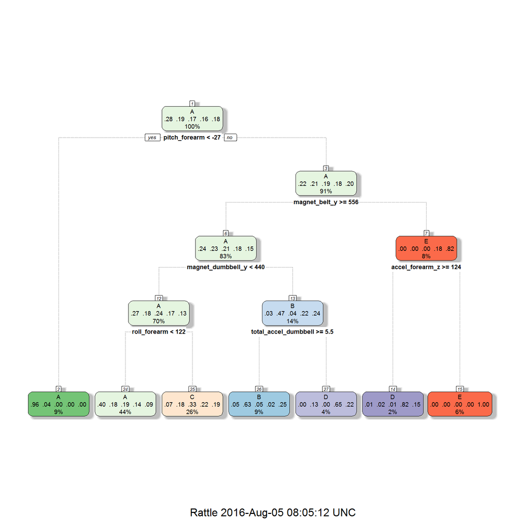

```r
suppressPackageStartupMessages(suppressWarnings(library(rattle)))
suppressPackageStartupMessages(suppressWarnings(library(rpart.plot)))
suppressPackageStartupMessages(suppressWarnings(library(e1071)))
fancyRpartPlot(rpartFull)
```

**Out-of-sample prediction: rpart**

```r
pred_rPart <- predict(rpartFull, testing_set, type = "class")
confusionMatrix(pred_rPart, testing_set$classe)
```

```
## Confusion Matrix and Statistics
##
##           Reference
## Prediction    A    B    C    D    E
##          A 2038  656  619  509  321
##          B   25  465   50   15  210
##          C  167  347  698  445  370
##          D    0   50    1  317   97
##          E    2    0    0    0  444
##
## Overall Statistics
##
##                Accuracy : 0.505
##                  95% CI : (0.4938, 0.5161)
##     No Information Rate : 0.2845
##     P-Value [Acc > NIR] : < 2.2e-16
##
##                   Kappa : 0.3535
##  Mcnemar's Test P-Value : < 2.2e-16
##
## Statistics by Class:
##
##                      Class: A Class: B Class: C Class: D Class: E
## Sensitivity            0.9131  0.30632  0.51023  0.24650  0.30791
## Specificity            0.6250  0.95259  0.79484  0.97744  0.99969
## Pos Pred Value         0.4919  0.60784  0.34435  0.68172  0.99552
## Neg Pred Value         0.9476  0.85129  0.88486  0.86872  0.86514
## Prevalence             0.2845  0.19347  0.17436  0.16391  0.18379
## Detection Rate         0.2598  0.05927  0.08896  0.04040  0.05659
## Detection Prevalence   0.5280  0.09750  0.25835  0.05927  0.05684
## Balanced Accuracy      0.7691  0.62946  0.65254  0.61197  0.65380
```

**Not useful for predicting anything, not really unexpected**  
**Setting up maxdept to 30 would most likely give better prediction, but it is wayoff a useful accuracy, so no point in testing that**.

### **Trying GBM (Generalized Boosted Regression)**

**Computational demanding…coffee time**

```r
cvCtrl <- trainControl(method = "repeatedcv", repeats = 1, number = 4)
suppressPackageStartupMessages(suppressWarnings(trained_GBM <- train(classe ~ ., data = training_set, method = "gbm", trControl = cvCtrl, verbose = FALSE)))
```

**Out-of-sample prediction: GBM**

```r
pred_trained_rpart <- suppressPackageStartupMessages(suppressWarnings(predict(trained_GBM, testing_set)))
confusionMatrix(pred_trained_rpart, testing_set$classe)
```

```
## Confusion Matrix and Statistics
##
##           Reference
## Prediction    A    B    C    D    E
##          A 2188   59    1    1    4
##          B   30 1413   51   12   17
##          C    4   36 1295   51   14
##          D    5    3   19 1208   13
##          E    5    7    2   14 1394
##
## Overall Statistics
##
##                Accuracy : 0.9556
##                  95% CI : (0.9509, 0.9601)
##     No Information Rate : 0.2845
##     P-Value [Acc > NIR] : < 2.2e-16
##
##                   Kappa : 0.9439
##  Mcnemar's Test P-Value : 2.849e-07
##
## Statistics by Class:
##
##                      Class: A Class: B Class: C Class: D Class: E
## Sensitivity            0.9803   0.9308   0.9466   0.9393   0.9667
## Specificity            0.9884   0.9826   0.9838   0.9939   0.9956
## Pos Pred Value         0.9711   0.9278   0.9250   0.9679   0.9803
## Neg Pred Value         0.9921   0.9834   0.9887   0.9882   0.9925
## Prevalence             0.2845   0.1935   0.1744   0.1639   0.1838
## Detection Rate         0.2789   0.1801   0.1651   0.1540   0.1777
## Detection Prevalence   0.2872   0.1941   0.1784   0.1591   0.1812
## Balanced Accuracy      0.9844   0.9567   0.9652   0.9666   0.9812
```

**OK Accuracy, even with the reduced trainControl settings**

### **RandomForest metod**

```r
library(randomForest)
suppressPackageStartupMessages(suppressWarnings(library(AppliedPredictiveModeling)))
suppressPackageStartupMessages(suppressWarnings(library(randomForest)))
RF_model <- randomForest(classe ~. , data = training_set)
```

```r
RF_model
```

```
##
## Call:
##  randomForest(formula = classe ~ ., data = training_set)
##                Type of random forest: classification
##                      Number of trees: 500
## No. of variables tried at each split: 6
##
##         OOB estimate of  error rate: 0.67%
## Confusion matrix:
##      A    B    C    D    E class.error
## A 3342    4    0    0    2 0.001792115
## B   15 2259    5    0    0 0.008775779
## C    0   17 2036    1    0 0.008763389
## D    0    0   23 1904    3 0.013471503
## E    0    0    2    7 2156 0.004157044
```

**Out-of-sample prediction: RandomForest**

```r
pred_RF <- predict(RF_model, testing_set)
```

```r
confusionMatrix(pred_RF, testing_set$classe)
```

```
## Confusion Matrix and Statistics
##
##           Reference
## Prediction    A    B    C    D    E
##          A 2228   13    0    0    0
##          B    2 1501   11    0    0
##          C    0    4 1356   18    5
##          D    0    0    1 1268    4
##          E    2    0    0    0 1433
##
## Overall Statistics
##
##                Accuracy : 0.9924
##                  95% CI : (0.9902, 0.9942)
##     No Information Rate : 0.2845
##     P-Value [Acc > NIR] : < 2.2e-16
##
##                   Kappa : 0.9903
##  Mcnemar's Test P-Value : NA
##
## Statistics by Class:
##
##                      Class: A Class: B Class: C Class: D Class: E
## Sensitivity            0.9982   0.9888   0.9912   0.9860   0.9938
## Specificity            0.9977   0.9979   0.9958   0.9992   0.9997
## Pos Pred Value         0.9942   0.9914   0.9805   0.9961   0.9986
## Neg Pred Value         0.9993   0.9973   0.9981   0.9973   0.9986
## Prevalence             0.2845   0.1935   0.1744   0.1639   0.1838
## Detection Rate         0.2840   0.1913   0.1728   0.1616   0.1826
## Detection Prevalence   0.2856   0.1930   0.1763   0.1622   0.1829
## Balanced Accuracy      0.9979   0.9934   0.9935   0.9926   0.9967
```

**RandomForest method wins!**

### **Predicting the classes of the validation set using the randomforest model**.

```r
valid <- predict(RF_model, testing_org)
valid
```

```
##  1  2  3  4  5  6  7  8  9 10 11 12 13 14 15 16 17 18 19 20
##  B  A  B  A  A  E  D  B  A  A  B  C  B  A  E  E  A  B  B  B
## Levels: A B C D E
```